DAND - Explore and Summarise Data - Red Wine Analysis By Alex Mathew 10th October 2017 ========================================================

> **AIM**: I have chosen the Red Wine dataset for this project. The aim with this project is to find interesting relationships between the chemical properties of the wine and its quality.

> **Basic Details**: Lets first have a look at the dataset and summarise what we have been given.

```
## 'data.frame':    1599 obs. of  13 variables:
##  $ X                   : int  1 2 3 4 5 6 7 8 9 10 ...
##  $ fixed.acidity       : num  7.4 7.8 7.8 11.2 7.4 7.4 7.9 7.3 7.8 7.5 ...
##  $ volatile.acidity    : num  0.7 0.88 0.76 0.28 0.7 0.66 0.6 0.65 0.58 0.5 ...
##  $ citric.acid         : num  0 0 0.04 0.56 0 0 0.06 0 0.02 0.36 ...
##  $ residual.sugar      : num  1.9 2.6 2.3 1.9 1.9 1.8 1.6 1.2 2 6.1 ...
##  $ chlorides           : num  0.076 0.098 0.092 0.075 0.076 0.075 0.069 0.065 0.073 0.071 ...
##  $ free.sulfur.dioxide : num  11 25 15 17 11 13 15 15 9 17 ...
##  $ total.sulfur.dioxide: num  34 67 54 60 34 40 59 21 18 102 ...
##  $ density             : num  0.998 0.997 0.997 0.998 0.998 ...
##  $ pH                  : num  3.51 3.2 3.26 3.16 3.51 3.51 3.3 3.39 3.36 3.35 ...
##  $ sulphates           : num  0.56 0.68 0.65 0.58 0.56 0.56 0.46 0.47 0.57 0.8 ...
##  $ alcohol             : num  9.4 9.8 9.8 9.8 9.4 9.4 9.4 10 9.5 10.5 ...
##  $ quality             : int  5 5 5 6 5 5 5 7 7 5 ...
```

```
##        X          fixed.acidity   volatile.acidity  citric.acid
##  Min.   :   1.0   Min.   : 4.60   Min.   :0.1200   Min.   :0.000
##  1st Qu.: 400.5   1st Qu.: 7.10   1st Qu.:0.3900   1st Qu.:0.090
##  Median : 800.0   Median : 7.90   Median :0.5200   Median :0.260
##  Mean   : 800.0   Mean   : 8.32   Mean   :0.5278   Mean   :0.271
##  3rd Qu.:1199.5   3rd Qu.: 9.20   3rd Qu.:0.6400   3rd Qu.:0.420
##  Max.   :1599.0   Max.   :15.90   Max.   :1.5800   Max.   :1.000
##  residual.sugar     chlorides       free.sulfur.dioxide
##  Min.   : 0.900   Min.   :0.01200   Min.   : 1.00
##  1st Qu.: 1.900   1st Qu.:0.07000   1st Qu.: 7.00
##  Median : 2.200   Median :0.07900   Median :14.00
##  Mean   : 2.539   Mean   :0.08747   Mean   :15.87
##  3rd Qu.: 2.600   3rd Qu.:0.09000   3rd Qu.:21.00
##  Max.   :15.500   Max.   :0.61100   Max.   :72.00
##  total.sulfur.dioxide    density             pH          sulphates
##  Min.   :  6.00       Min.   :0.9901   Min.   :2.740   Min.   :0.3300
##  1st Qu.: 22.00       1st Qu.:0.9956   1st Qu.:3.210   1st Qu.:0.5500
##  Median : 38.00       Median :0.9968   Median :3.310   Median :0.6200
##  Mean   : 46.47       Mean   :0.9967   Mean   :3.311   Mean   :0.6581
##  3rd Qu.: 62.00       3rd Qu.:0.9978   3rd Qu.:3.400   3rd Qu.:0.7300
##  Max.   :289.00       Max.   :1.0037   Max.   :4.010   Max.   :2.0000
##     alcohol         quality
##  Min.   : 8.40   Min.   :3.000
##  1st Qu.: 9.50   1st Qu.:5.000
##  Median :10.20   Median :6.000
##  Mean   :10.42   Mean   :5.636
##  3rd Qu.:11.10   3rd Qu.:6.000
##  Max.   :14.90   Max.   :8.000
```

```
##    Min. 1st Qu.  Median    Mean 3rd Qu.    Max.
##   3.000   5.000   6.000   5.636   6.000   8.000
```

> **What we can observe :**: 1. We can see that there are 1599 observations of 13 variables.  
> 2. X is a identifier, numerically increasing.  
> 3. There are two acidity variables and two sulphur.dioxide variables.

```
##    Min. 1st Qu.  Median    Mean 3rd Qu.    Max.
##   3.000   5.000   6.000   5.636   6.000   8.000
```

```
##
##   3   4   5   6   7   8
##  10  53 681 638 199  18
```

```
##  Ord.factor w/ 6 levels "3"<"4"<"5"<"6"<..: 3 3 3 4 3 3 3 5 5 3 ...
```

# Univariate Plots Section

> **Initial Exploration**: In this section, we perform some preliminary exploration of your dataset. Run some summaries of the data and create univariate plots to understand the structure of the individual variables in the dataset.

We plot histogram plots for each variable to see how it looks.

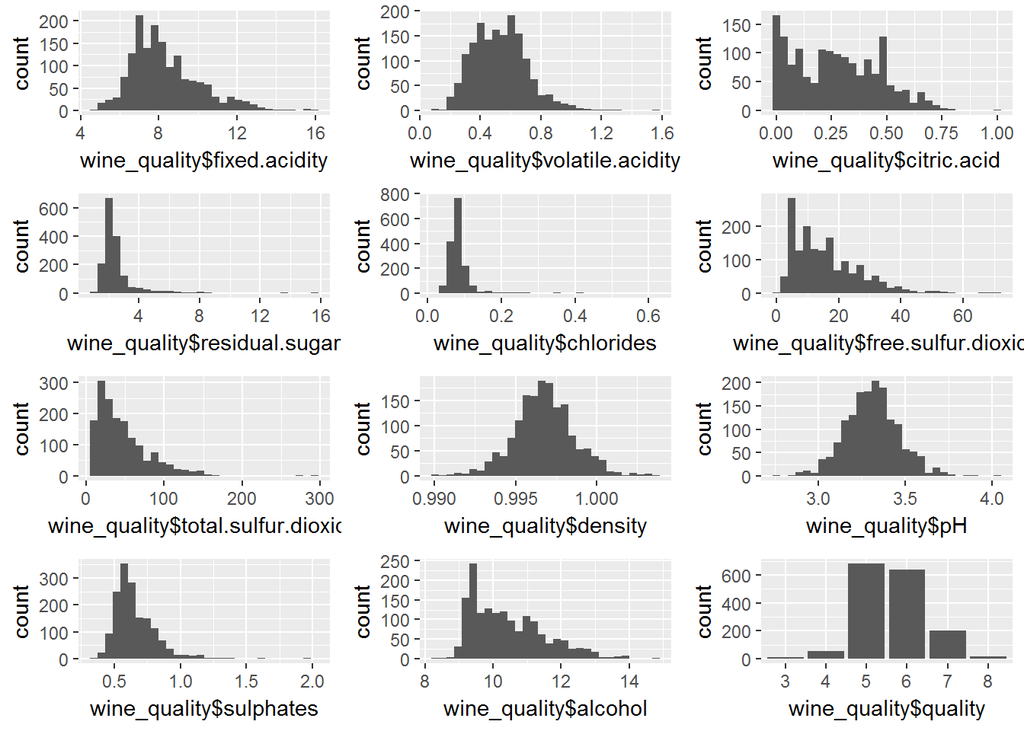

The above plots are histograms that show the details for each of the 12 variables. It seems that some variables are normally distributed while some are long tailed. Using these plots we can gleam quite a lot of information like the mean ph of the wine data lies between 3 and 3.5 and that most of the wine data has residual sugar less than 4.

# Univariate Analysis

First lets look the main characteristic :

> **Quality of the wine**: It has a range of 3 to 8 and kind of resembles a normal distribution. Most recieved a rating of 5 and 6 while extreme ratings of 3 and 8 have much smaller values. I am going to divide the data into three sets depending on a new ‘rating’ value based on the following rule -  
> Bad - 4 and below  
> Normal - 5 and 6  
> Good - 7 and above Also I will be creating a combined variable for acidity ‘total.acidity’ as  
> these actually represent tartaric and acetic acid respectively. Plots for these two new variables is also created.

```
##    Bad Normal   Good
##     63   1319    217
```

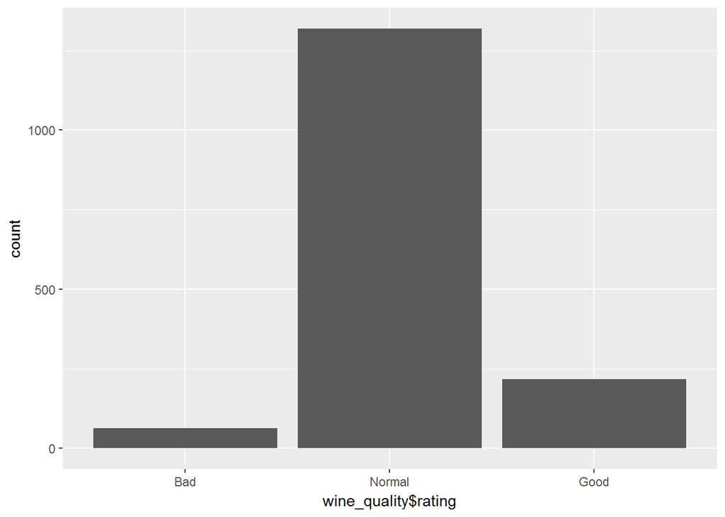

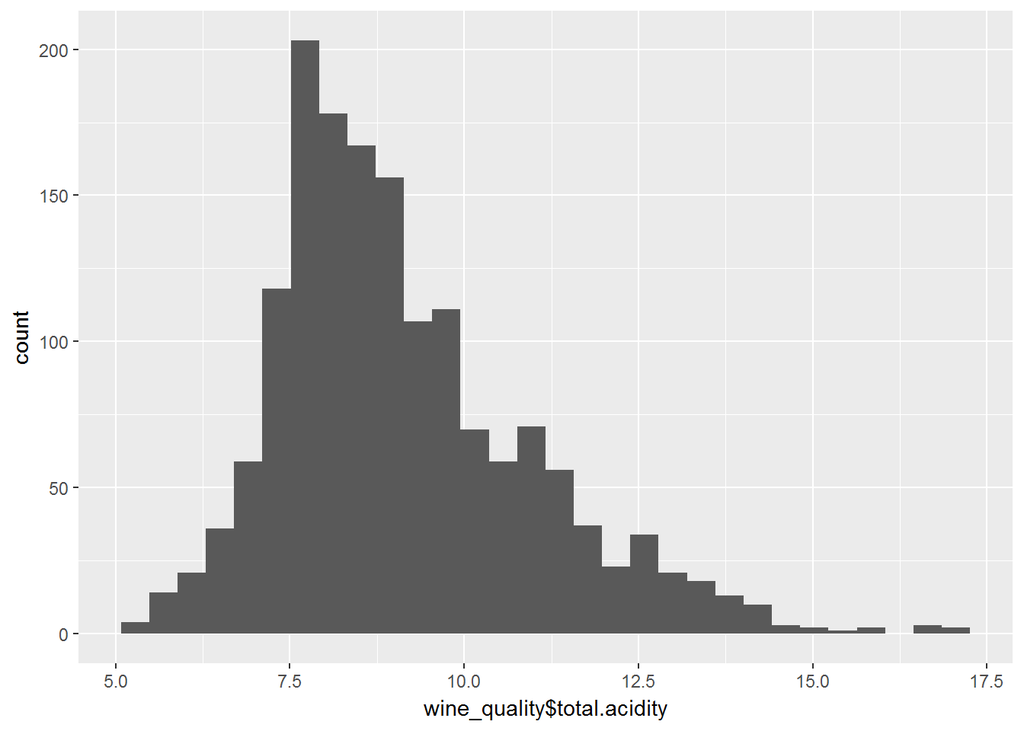

The first figure gives a summary of the wine data distribution across the rating. The second plot depicts the above information. We can see that almost 1320 wine data belonged to the average classification.  
The third plot shows the distribution of the wine data based on the total acidic content.

> **Density,Ph and others**:  
> 1. Density and Ph appear to be normally distributed with minimal outliers.  
> 2. The alcohol,acidity and sulphur variables have a noticeable long tailed shape.  
> 3. Sugar and chloride have extreme values.  
> 4. Citric acid variables have a lot of zero values which is surprising.